# Real Estate Pricing

### 10.0.4 Distribution of Number of Rooms

The bar chart illustrates the frequency of properties based on the number of rooms. Properties with 3 to 4 rooms are the most common, which aligns with the predominance of smaller property sizes seen in the previous chart.

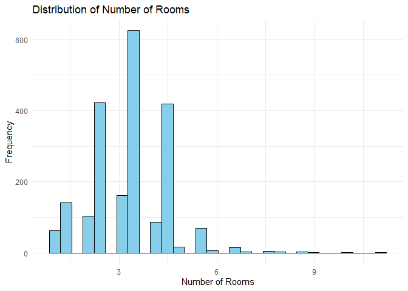

### 10.0.5 Effect of Number of Rooms on Rental Price

This scatter plot explores how the number of rooms affects the gross rental price. While there is a general trend of increasing rental prices with more rooms, the variability in price also increases, as indicated by the spread of data points.

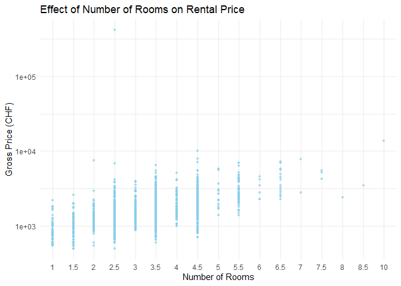

# 11 Data Modeling

# 12 Linear Model

## 12.1 Purpose and Target

We decided to employ a linear regression model in order to predict prices for different rental properties, specifically apartments. We created three different models, each taking into account different features to help us gain better insight.

### 12.1.1 Linear Model 1

The first model (*all_lm_model*)takes all available property features into account to train and make predictions. From this we were able to see that some of those we included were not relevant to the target variable, as seen below:

```
##
## Call:
## lm(formula = Price_Gross ~ ., data = train_set)
##
## Residuals:
##     Min      1Q  Median      3Q     Max
## -2176.5  -520.6  -127.7   291.5  8029.0
##
## Coefficients: (6 not defined because of singularities)
##                        Estimate Std. Error t value Pr(>|t|)
## (Intercept)           -330.2945   150.2993  -2.198  0.02830 *
## Canton_num2            254.4067   148.3181   1.715  0.08673 .
## Canton_num3            483.3631    99.2194   4.872 1.36e-06 ***
## Days_Difference          4.8306     1.1046   4.373 1.41e-05 ***
## Customer_Segment_num2  372.1311   113.1334   3.289  0.00105 **
## Category_num2         1313.0156   209.7461   6.260 6.62e-10 ***
## Nr_rooms               392.9436    37.3741  10.514  < 2e-16 ***
## Package_Product_num2    74.9385   146.7752   0.511  0.60981
## Package_Product_num3   -42.5430   149.3823  -0.285  0.77589
## Package_Product_num4         NA         NA      NA       NA
## GDP_2020_21                  NA         NA      NA       NA
## GDP_per                      NA         NA      NA       NA
## Population                   NA         NA      NA       NA
## Area_km2                     NA         NA      NA       NA
## Density                      NA         NA      NA       NA
## Size_m2                  1.2904     0.5644   2.286  0.02253 *
## ---
## Signif. codes:  0 '***' 0.001 '**' 0.01 '*' 0.05 '.' 0.1 ' ' 1
##
## Residual standard error: 924 on 719 degrees of freedom
## Multiple R-squared:  0.3748, Adjusted R-squared:  0.367
## F-statistic: 47.89 on 9 and 719 DF,  p-value: < 2.2e-16
```

### 12.1.2 Linear Model 2

The next model ( *few_lm_model* ) we trained with fewer dependent variables, only those of high importance. For this one, we took into account only the ones that were calculated to be significant to the model’s performance.

```
##
## Call:
## lm(formula = Price_Gross ~ ., data = rel_train_set)
##
## Residuals:
##     Min      1Q  Median      3Q     Max
## -2229.4  -514.6  -141.5   293.3  8029.5
##
## Coefficients:
##                        Estimate Std. Error t value Pr(>|t|)
## (Intercept)           -331.4296   150.1187  -2.208   0.0276 *
## Canton_num2            252.9396   148.1582   1.707   0.0882 .
## Canton_num3            484.3610    99.1035   4.887 1.26e-06 ***
## Days_Difference          4.8187     1.1027   4.370 1.43e-05 ***
## Customer_Segment_num2  384.0690    77.0910   4.982 7.88e-07 ***
## Category_num2         1310.3480   209.3197   6.260 6.61e-10 ***
## Nr_rooms               393.1761    37.3357  10.531  < 2e-16 ***
## Size_m2                  1.2903     0.5639   2.288   0.0224 *
## ---
## Signif. codes:  0 '***' 0.001 '**' 0.01 '*' 0.05 '.' 0.1 ' ' 1
##
## Residual standard error: 923.1 on 721 degrees of freedom
## Multiple R-squared:  0.3742, Adjusted R-squared:  0.3682
## F-statistic:  61.6 on 7 and 721 DF,  p-value: < 2.2e-16
```

*Here we can see that the variables taken into account were Canton, Days_Difference, Category, Customer_Segment, Nr_rooms and Size_m2.*

### 12.1.3 Linear Model 3

```
##                Estimate Std. Error   t value     Pr(>|t|)
## (Intercept)    276.3230   121.5397  2.273521 2.328600e-02
## Nr_rooms       422.9314    34.9998 12.083822 9.238078e-31
## Category_num2 1474.6644   217.7799  6.771352 2.634720e-11
```

## 12.2 Interpretation

All three models offer us some insight into the behavior of rental prices for different properties. Interestingly, our research thus far shows that the Canton of said property is not that influential in its rental price, except for Canton 3.

*(Canton 1: Argau, Canton 2: Luzern, Canton 3: Zürich)*

For desired results, we will focus on the second model, which includes all the variables considered significant for the best results.

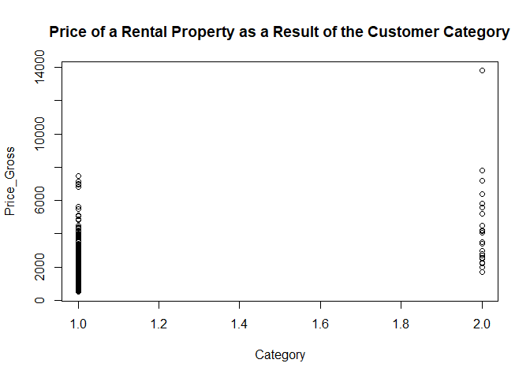

In this diagram we can observe that, though there are fewer instances of Category 2 (House) compared to Category 1 (Apartment), Category 2 properties tend to have higher rental prices. This does not, however, indicate that they may be the more lucrative option, as houses tend to incur other costs that are either not present, or the cost is split in the community, in the case of apartments.

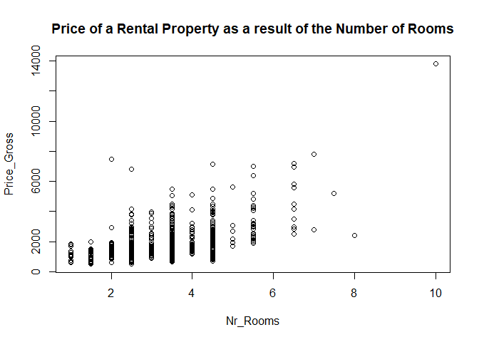

In the illustration above, we depict the relationship between the number of rooms in a property and the gross price of the same. We can observe an upward curve, which leads to believe that a higher number of rooms leads to a higher price, which would make sense. This information must also be taken into consideration together with other variables, like the property’s area in meters squared, average size of rooms, location, etc.

## 12.3 Conclusion

Our linear models suggest that properties, specifically houses, with more rooms go for a higher price. This doesn’t necessarily indicate that they may be the best choice for renting out to customers, but it does suggest that they are the properties which generate the highest gross payment on a regular basis.

# 13 Neural Network

## 13.1 Purpose and Target

When considering using a Neural Network, we decided to identify potential high value properties within the dataset. To do this, we engineered a new, binary column, identifying whether a property was considered “High-Ticket” or not. In order to categorize properties this way, we calculated the price per meter squared of each property, and those in the top quartile had their High_Ticket column value set to 1, others to 0.

With this transformation, we had created a binary classification problem: is this property a high-ticket property? Answering this question will allow us to filter out most properties which may not be as lucrative for Zug Estates, and offer only the cream of the crop as possible targets for acquisition.

## 13.2 Findings

After classifying the properties into either category, we were able to analyze the model’s performance on the dataset. If successful, this Neural Network will be a great tool in the future to predict a possible acquisition’s performance over time. Properties may be acquired at lower prices, and may not be very attractive at the time of purchase, but with some remodeling and updating the living space, its perceived value may be brought to a new high. This is what we try to predict with this model: the potential of a specific property and to discern if it could be a lucrative investment for Zug Estates.

```
##           Reference
## Prediction   0   1
##          0 143   2
##          1   0  38
```

*Confusion Matrix of the Neural Network’s performance.*

As seen in the previous matrix, the model’s performance on categorizing properties into possible high-ticket or not is quite good. This tool will help in the future, when looking at new properties, to have an idea of more or less how beneficial a specific property could be to Zug Estates’ portfolio.

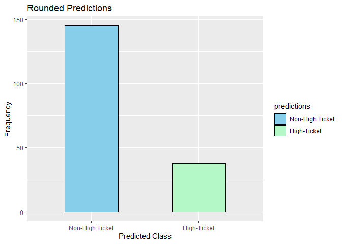

*Predictions have been rounded because some values fell into decimal places, due to the nature of the Neural Networks’ activation function (sigmoid curve)*

As we can see, not many values actually fall into the category of High-Ticket properties, so having a tool like this network will be beneficial in catching such opportunities early on and maximizing added value and profits for the real estate company.

# 14 Support Vector Machine

Though the Neural Network presented great results, we wanted to make sure to validate that it was the optimal choice for classification in our problem. Support Vector Machines (SVMs henceforth) also excel at binary classification problems, so we wanted to create one and train it on the same data in order to visualize and compare performance, to ensure we use the better performing model for recommending properties to acquire.

```
##           Reference
## Prediction   0   1
##          0 143   2
##          1   0  38
```

*Neural Network Performance*

```
##           Reference
## Prediction   0   1
##          0 133  16
##          1   3  31
```

*SVM Performance*

As we can see, comparing the two confusion matrices, the Neural Network has better accuracy than the SVM. Though at first glance it may seem like the better option, there are several advantages and disadvantages between the two models.

An SVM is particularly effective when working with higher-dimensional data, and has better memory efficiency. It is also more robust to overfitting, but are less efficient with larger datasets because of the training complexity.

Neural networks on the other hand, are more flexible and powerful when it comes to approximating trends. They can also learn and extract features that are not present in the data, finding new relationships that may not be obvious, but can be very computationally intensive.

In summary, both are good options for our purpose. In the future, if considering to use either one, the size, shape and complexity of the available dataset will play a pivotal role in the selection of the best model to use for finding possible “golden goose” properties.